### R commands for linear modeling

#### Fitting a model

The basic command for fitting a linear model in R is `lm()`. This takes as arguments a model formula and a data frame with the variables included in the model formula. For example:

```r
lm(height ~ mother, data = mosaicData::Galton)
```

```
##
## Call:
## lm(formula = height ~ mother, data = mosaicData::Galton)
##
## Coefficients:
## (Intercept)       mother
##     46.6908       0.3132
```

If there is one (or more covariates) to be included in the model, simply add it to the model formula, e.g.

```r
lm(height ~ mother + sex, data = mosaicData::Galton)
```

```
##
## Call:
## lm(formula = height ~ mother + sex, data = mosaicData::Galton)
##
## Coefficients:
## (Intercept)       mother         sexM
##     41.4495       0.3531       5.1767
```

##### Non-straight-line models

By default, the app uses a *first-order* polynomial as a model form. This is just a fancy way of saying that the model functions will be straight lines.

But … It’s not all just using fancy words. You can also tell the app to construct a second-, third-, or higher-order model. This enables the function to be more flexible.

##### Flat-line models

A zeroth-order function has a constant value, corresponding to a flat line in the graph. In a zeroth-order model, the explanatory variable is not being used at all.

##### Interaction with covariate

When there is a covariate in the model, the default behavior of the app is to include “interaction terms.” Without interactions, the model functions for different levels of the covariate will be parallel. The interaction enables the function to have a different shape for each level of the covariate.

#### Statistical reports

The regression and ANOVA reports presented in the “Statistics” tab can be generated by using the `summary()` and `anova()` functions, e.g.

```r
mod <- lm(height ~ mother * sex, data = mosaicData::Galton)
summary(mod)
#
#   Call:
#   lm(formula = height ~ mother * sex, data = mosaicData::Galton)
#
#   Residuals:
#       Min      1Q  Median      3Q     Max
#   -9.4152 -1.6036  0.1498  1.5885  9.3964
#
#   Coefficients:
#               Estimate Std. Error t value Pr(>|t|)
#   (Intercept) 43.15546    3.22229  13.393  < 2e-16 ***
#   mother       0.32655    0.05018   6.507 1.27e-10 ***
#   sexM         1.96331    4.41988   0.444    0.657
#   mother:sexM  0.05014    0.06892   0.727    0.467
#   ---
#   Signif. codes:  0 '***' 0.001 '**' 0.01 '*' 0.05 '.' 0.1 ' ' 1
#
#   Residual standard error: 2.375 on 894 degrees of freedom
#   Multiple R-squared:  0.5621,    Adjusted R-squared:  0.5606
#   F-statistic: 382.5 on 3 and 894 DF,  p-value: < 2.2e-16
anova(mod)
#   Analysis of Variance Table
#
#   Response: height
#               Df Sum Sq Mean Sq   F value Pr(>F)
#   mother       1  468.3   468.3   83.0121 <2e-16 ***
#   sex          1 6000.9  6000.9 1063.8395 <2e-16 ***
#   mother:sex   1    3.0     3.0    0.5293 0.4671
#   Residuals  894 5042.9     5.6
#   ---
#   Signif. codes:  0 '***' 0.001 '**' 0.01 '*' 0.05 '.' 0.1 ' ' 1
```

If there is not a covariate, the ANOVA report simply re-iterates the F-test presented in the regression report. ANOVA helps to indicate whether the covariate is contributing to the explanation of the response variable given by the model.

#### Graphics

The graphics produced by the app are quite complicated due to the display of the model outputs and raw values on the right-hand side of the graph. You can make such a graph with the `smoother_plot()` function in the `LittleApp` package. There’s is documentation with an example.

To make conventional graphics showing a straight-line model, use the `gf_lm()` function along with `gf_point()`, for instance …

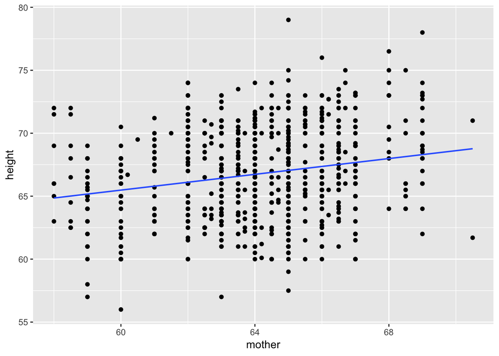

```r
gf_point(height ~ mother, data = Galton) %>%
  gf_lm()
```

If there is to be a categorical covariate used in the model, put that as the `color =` argument to `gf_point()`. Make sure to include the tilde in the `color =` argument.

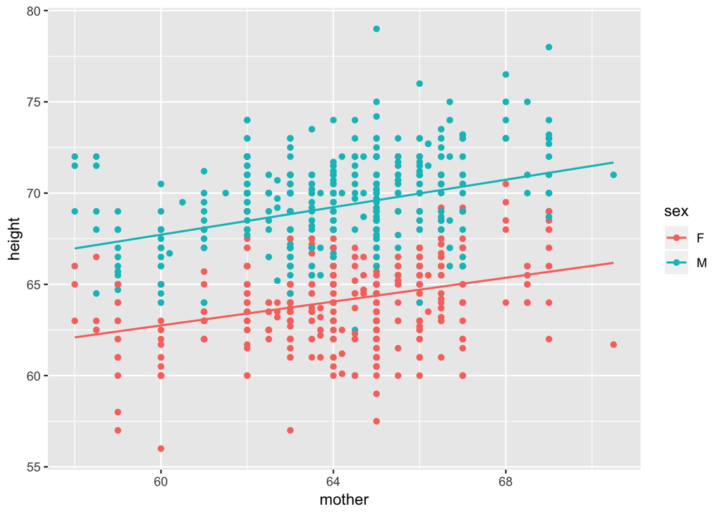

```r
gf_point(height ~ mother, color = ~ sex, data = Galton) %>%
  gf_lm()
```

If you want a more flexible model, use `gf_smooth()` instead of `gf_lm()`.

#### *For the mathematically inclined* …

The second- and higher-order models are not based on garden-variety polynomials. The polynomial form *must* have $\lim_{x \rightarrow \pm \infty} y \rightarrow \pm \infty$. This makes it badly behaved for modeling; extrapolation in either direction leads to implausible values of $y$ even for small amounts of extrapolation. One way to think of a polynomial model is like a dog in a squirrel-filled park. As long as the dog is leashed to the data, everything is fine. But if the dog gets away from the data, it’s going to run off uncontrollably hunting squirrels: bad behavior.

Instead of polynomials, the app uses a more appropriate basis set for general-purpose modeling: natural cubic splines. Extrapolation away from the data is always linear, which is much better behavior. The model formula uses `ns()` on the explanatory variable to create the basis set, e.g. `height ~ ns(mother, 3)` for a third-order model.